# Problem Set 4

Program Evaluation and Causal Inference

Christian Birchler

Fenqi Guo

Mingrui Zhang

Wenjie Tu

Zunhan Zhang

Spring Semester 2021

# Instrumental Variables

## 1. Bias of the IV estimator

$$y_i=\beta_0+\beta_1x_i+u_i$$

### 1(a)

$$\begin{aligned}
\hat{\beta}_{IV}&=\frac{\widehat{Cov(y_i,z_i)}}{\widehat{Cov(x_i,z_i)}} \\
&=\frac{\sum_{i=1}^n(z_i-\overline{z})(y_i-\overline{y})}
{\sum_{i=1}^n(z_i-\overline{z})(x_i-\overline{x})} \\
&=\frac{\sum_{i=1}^n(z_iy_i-z_i\overline{y}-y_i\overline{z}+\overline{y}\overline{z})}
{\sum_{i=1}^n(z_ix_i-z_i\overline{x}-x_i\overline{z}+\overline{x}\overline{z})} \\
&=\frac{\sum_{i=1}^n(z_iy_i-y_i\overline{z})-\overline{y}\sum_{i=1}^nz_i+n\overline{y}\overline{z}}
{\sum_{i=1}^n(z_ix_i-x_i\overline{z})-\overline{x}\sum_{i=1}^nz_i+n\overline{x}\overline{z}} \\
&=\frac{\sum_{i=1}^n(z_iy_i-y_i\overline{z})-n\overline{y}\overline{z}+n\overline{y}\overline{z}}
{\sum_{i=1}^n(z_ix_i-x_i\overline{z})-n\overline{x}\overline{z}+n\overline{x}\overline{z}} \\
&=\frac{\sum_{i=1}^n(z_i-\overline{z})y_i}
{\sum_{i=1}^n(z_i-\overline{z})x_i}
\end{aligned}$$

### 1(b)

$$\begin{aligned}
\hat{\beta}_{IV}&=\frac{\sum_{i=1}^n(z_i-\overline{z})y_i}
{\sum_{i=1}^n(z_i-\overline{z})x_i} \\
&=\frac{\sum_{i=1}^n(z_i-\overline{z})(\beta_0+\beta_1x_i+u_i)}
{\sum_{i=1}^n(z_i-\overline{z})x_i} \\
&=\frac{\beta_0\sum_{i=1}^n(z_i-\overline{z})+
\beta_1\sum_{i=1}^n(z_i-\overline{z})x_i+\sum_{i=1}^n(z_i-\overline{z})u_i}
{\sum_{i=1}^n(z_i-\overline{z})x_i} \\
&=\beta_1+\frac{\sum_{i=1}^n(z_i-\overline{z})u_i}
{\sum_{i=1}^n(z_i-\overline{z})x_i}
\end{aligned}$$

### 1(c)

$$\begin{aligned}
p\lim(\hat{\beta}_{IV}-\beta_1)&=\frac{p\lim\sum_{i=1}^n(z_i-\overline{z})u_i}
{p\lim\sum_{i=1}^n(z_i-\overline{z})x_i} \\
&=\frac{p\lim\sum_{i=1}^n(z_i-\overline{z})(u_i-\overline{u})}
{p\lim\sum_{i=1}^n(z_i-\overline{z})(x_i-\overline{x})} \\
&=\frac{p\lim\frac{1}{n}\sum_{i=1}^n(z_i-\overline{z})(u_i-\overline{u})}
{p\lim\frac{1}{n}\sum_{i=1}^n(z_i-\overline{z})(x_i-\overline{x})} \\
&\approx\frac{Cov(z_i,u_i)}{Cov(z_i, x_i)}=0
\end{aligned}$$
$\hat{\beta}_{IV}$ is a consistent estimator of $\beta_1$.

### 1(d)

In a small sample, $\hat{\beta}_{IV}$ is biased. But as the sample increases, $\beta_{IV}$ will probability converge to the $\beta_1$. Therefore, in a large sample, IV estimator will never affect the consistency of the true estimator regardless of whether there exists an endogenous problem.

## 2. Derivation of the Wald estimator

### 2(a)

From question 1, we know that

$$\begin{aligned}
\delta^{W}=\hat{\beta}_1&=\frac{Cov(y_i,z_i)}{Cov(d_i,z_i)} \\
&=\frac{\mathbb{E}(y_i|z_i=1)-\mathbb{E}(y_i|z_i=1)}
{\mathbb{E}(d_i|z_i=1)-\mathbb{E}(d_i|z_i=1)}
\\
&=\frac{\mathbb{E}(\beta_1+\beta_1d_i+u_i|z_i=1)-\mathbb{E}(\beta_1+\beta_1d_i+u_i|z_i=0)}
{\mathbb{E}(d_i|z_i=1)-\mathbb{E}(d_i|z_i=0)} \\
&=\frac{\beta_1\mathbb{E}(d_i|z_i=1)+\mathbb{E}(u_i|z_i=1)-
\beta_1\mathbb{E}(d_i|z_i=0)-\mathbb{E}(u_i|z_i=0)}
{\mathbb{E}(d_i|z_i=1)-\mathbb{E}(d_i|z_i=0)} \\
&=\frac{\beta_1(\mathbb{E}(d_i|z_i=1)-\mathbb{E}(d_i|z_i=0))+
\mathbb{E}(u_i|z_i=1)-\mathbb{E}(u_i|z_i=0) }
{\mathbb{E}(d_i|z_i=1)-\mathbb{E}(d_i|z_i=0)} \\
&=\beta_1+\frac{\mathbb{E}(u_i|z_i=1)-\mathbb{E}(u_i|z_i=0)}
{\mathbb{E}(d_i|z_i=1)-\mathbb{E}(d_i|z_i=0)}
\end{aligned}$$

### 2(b)

In order to identify $\beta_1$ using the instrument, we need
$$\frac{\mathbb{E}(u_i|z_i=1)-\mathbb{E}(u_i|z_i=0)}
{\mathbb{E}(d_i|z_i=1)-\mathbb{E}(d_i|z_i=0)}=0
\iff
\mathbb{E}(u_i|z_i=1)=\mathbb{E}(u_i|z_i=0)$$

Only instrument assumption can be tested empirically. The vadility of other assumptions must be assessd on a case-by-case basis.

## 3. Self selection revisited

$$\begin{aligned}
D_i&=\pmb{1}(Y_{1i}-Y_{0i}>0) \\
&=\pmb{1}(\beta_1+u_{1i}-u_{0i}>0)
\end{aligned}$$

$$\begin{aligned}
\Delta^{\text{ATE}}&=\mathbb{E}(Y_{1i}-Y_{0i}) \\
&=\mathbb{E}[(\beta_0+\beta_1+u_{1i})-(\beta_0+u_{0i})] \\
&=\mathbb{E}(\beta_1+u_{1i}-u_{0i}) \\
&=\mathbb{E}(\beta_1)+\mathbb{E}(u_{1i})+\mathbb{E}(u_{0i}) \\
&=\beta_1>0
\end{aligned}$$

$$\begin{aligned}
\Delta^{\text{ATT}}&=\mathbb{E}(Y_{1i}-Y_{0i}|D=1) \\
&=\mathbb{E}(\beta_1+u_{1i}-u_{0i}|D=1) \\
&=\beta_1+\mathbb{E}(u_{1i}-u_{0i}|D=1) \\
&=\Delta^{\text{ATE}}+\mathbb{E}(u_{1i}-u_{0i}|D=1) \\
\mathbb{E}(u_{1i}-u_{0i}|D=1)&=\mathbb{E}(u_{1i}-u_{0i}|\beta_1+u_{1i}-u_{0i}>0) \\
&=\mathbb{E}(u_{1i}-u_{0i}|u_{1i}-u_{0i}>-\beta_1)>0
\end{aligned}$$
ATT is larger than ATE.

### 3(b)

$$\begin{aligned}
\Delta^{\text{naive}}&=\mathbb{E}(Y_{1i}|D=1)-\mathbb{E}(Y_{0i}|D=0)\\
&=\mathbb{E}(Y_{1i}|D=1)-\mathbb{E}(Y_{0i}|D=0)
\color{red}{-\mathbb{E}(Y_{0i}|D=1)+\mathbb{E}(Y_{0i}|D=1)} \\
&=\underbrace{\mathbb{E}(Y_{1i}|D=1)-\mathbb{E}(Y_{0i}|D=1)}_{\Delta^{\text{ATT}}}+
\underbrace{\mathbb{E}(Y_{0i}|D=1)-\mathbb{E}(Y_{0i}|D=0)}_\text{selection bias}
\end{aligned}$$

$$\begin{aligned}
\text{selection bias}&=\mathbb{E}(Y_{0i}|D=1)-\mathbb{E}(Y_{0i}|D=0) \\
&=\mathbb{E}(\beta_0+u_{0i}|\beta_1+u_{1i}-u_{0i}>0)-\mathbb{E}(\beta_0+u_{0i}|u_{1i}-u_{0i}\leq0) \\
&=\mathbb{E}(u_{0i}|u_{1i}-u_{0i}>-\beta_1)-\mathbb{E}(u_{0i}|u_{1i}-u_{0i}\leq0) \\
&=\mathbb{E}(u_{0i}|u_{1i}-u_{0i}>-\beta_1)-\mathbb{E}(u_{0i}|u_{1i}-u_{0i}>0)
\quad\text{symmetric distribution} \\
&>0
\end{aligned}$$

If individuals can self-select themselves into the program, the naive estimator will be larger since the selection bias is positive ($\mathbb{E}(Y_{0i}|D=1)>\mathbb{E}(Y_{0i}|D=0)$)

### 3(c)

$$\begin{aligned}
\text{LATE}&=\frac{\mathbb{E}(Y|Z=1)-\mathbb{E}(Y|Z=0)}
{\mathbb{E}(D|Z=1)-\mathbb{E}(D|Z=0)} \\
&=\frac{\mathbb{E}(Y|Z=1)-\mathbb{E}(Y|Z=0)}{\mathbb{E}(D_{1i}|Z=1)-\mathbb{E}(D_{0i}|Z=0)} \\
&=\frac{\mathbb{E}(Y|Z=1)-\mathbb{E}(Y|Z=0)}{\mathbb{E}(\pmb{1}(Y_{1i}-Y_{0i}+1>0))-
\mathbb{E}(\pmb{1}(Y_{1i}-Y_{0i}>0))} \\
&=\frac{\mathbb{E}(Y|Z=1)-\mathbb{E}(Y|Z=0)}{\mathbb{E}(\pmb{1}(\beta_1+u_{1i}-u_{0i}+1>0))-
\mathbb{E}(\pmb{1}(\beta_1+u_{1i}-u_{0i}>0))} \\
&=\frac{\mathbb{E}(Y|Z=1)-\mathbb{E}(Y|Z=0)}{\mathbb{E}(\beta_1+u_{1i}-u_{0i}+1)-
\mathbb{E}(\beta_1+u_{1i}-u_{0i})} \\
&=\mathbb{E}(Y|Z=1)-\mathbb{E}(Y|Z=0) \\
&=\text{ITT}
\end{aligned}$$

### 3(d)

$$\text{LATE}=\frac{\text{ITT}}{\text{proportion of compliers}}=\text{ITT}$$
We can derive that the proportion of compliers in the randomization experiment is 1. In other words, the instrument is randomly assigned with perfect compliance. Therefore, LATE=ATE.

## 4. Application: Angrist’s (1990) study on military service

### 4(a)

$$\ln(\widehat{\text{earnings}_i})=6.4364
\underbrace{-0.0255}_\text{treatment effect}\cdot\text{veteran}_i+
\underbrace{\beta\cdot x_i}_\text{other omitted control variables}$$

Earnings are not only determined by the veteran status. There are some omitted variables.

### 4(b)

|  | $Z=0$ | $Z=1$ |
| --- | --- | --- |
| $D=0$ | 5,928 | 1,875 |
| $D=1$ | 1,400 | 863 |

### 4(c)

|  | $Z=0$ | $Z=1$ |
| --- | --- | --- |
| $D=0$ | $\widehat{\mathbb{E}(Y)}=6.4472$ | $\widehat{\mathbb{E}(Y)}=6.4028$ |
| $D=1$ | $\widehat{\mathbb{E}(Y)}=6.4076$ | $\widehat{\mathbb{E}(Y)}=6.4289$ |

In $Z=0$ group:
$$\frac{p_C}{p_N+p_C}\times \mathbb{E}(Y_0|Z=0,C)+\frac{p_N}{p_N+p_C}\times
\mathbb{E}(Y_0|Z=0,N)=6.4472 \implies
\mathbb{E}(Y_0|Z=0,C)=6.666$$

In $Z=1$ group:
$$\frac{p_C}{p_A+p_C}\times \mathbb{E}(Y_1|Z=1,C)+\frac{p_A}{p_A+p_C}\times
\mathbb{E}(Y_1|Z=1,A)=6.4289 \implies
\mathbb{E}(Y_1|Z=1,C)=6.4691$$

### 4(d)

$$\begin{aligned}
\delta&=\frac{\mathbb{E}(Y|Z=1)-\mathbb{E}(Y|Z=0)}{\mathbb{E}(Y|Z=1)-\mathbb{E}(Y|Z=0)} \\
&=\frac{p_C[\mathbb{E}(Y_1|Z=1,C)-\mathbb{E}(Y_0|Z=0,C)]}{p_C} \\
&=\mathbb{E}(Y_1|Z=1,C)-\mathbb{E}(Y_0|Z=0,C) \\
&=6.4691-6.666 \\
&=-0.1969
\end{aligned}$$

## 5. IV in action

### 5(a)

```r
# load relevant libraries
library(haven) # read dta file
library(lattice) # density plot
library(stargazer) # print summary statistics
library(AER) # iv regression
```

```r
d.mort <- read_dta('mortality.dta')
```

```r
# outcome of interest
summary(d.mort$before67dead)
```

```
##    Min. 1st Qu.  Median    Mean 3rd Qu.    Max.
## 0.00000 0.00000 0.00000 0.07311 0.00000 1.00000
```

```r
# treatment
summary(d.mort$dist65_ageATend4emp)
```

```
##    Min. 1st Qu.  Median    Mean 3rd Qu.    Max.
##  -4.833   5.000   6.333   6.499   8.000  11.000
```

```r
# instrument
summary(d.mort$Zd_during)
```

```
##    Min. 1st Qu.  Median    Mean 3rd Qu.    Max.
##  0.0000  0.0000  0.0000  0.4787  1.0000  1.0000
```

### 5(b)

```r
model.ols1 <- lm(before67dead ~ dist65_ageATend4emp + czeit1yATage50 +
                   czeit2yATage50 + czeit5yATage50 + czeit10yATage50 +
                   czeit25yATage50 + I(czeit1yATage50^2) + I(czeit2yATage50^2) +
                   I(czeit5yATage50^2) + I(czeit10yATage50^2) +
                   I(czeit25yATage50^2) + as.factor(halfyearOFbirth) +
                   as.factor(nutsATage50), data=d.mort)

model.ols2 <- lm(before67dead ~ dist65_ageATend4emp, data=d.mort)

stargazer(model.ols1, model.ols2, keep.stat='n', header=F,
          keep='dist65_ageATend4emp', font.size='small',
          column.labels=c('Control', 'Non-control'), digits=4,
          title='Comparison between control and non-control')
```

[output not shown]

### 5(c)

Significance

We can reject the null hypothesis in both cases but we are more confident to reject $\beta_1=0$ with control variables.

### 5(d)

Omitted-variable bias

Health status. If people are in a bad physical condition, they are more likely to spend less years in their early retirement or even die before retirement. Therefore, the estimator for $\beta_1$ is biased upwards and we expect a positive bias.

### 5(e)

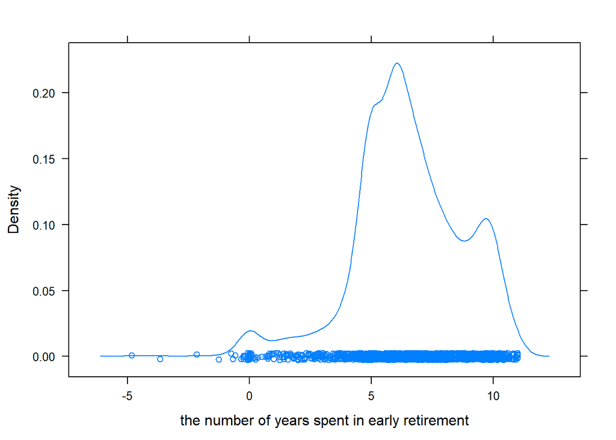

```r
densityplot(~ d.mort$dist65_ageATend4emp, auto.key = TRUE,
            xlab = 'the number of years spent in early retirement',
            data = data.frame(treatment=d.mort$dist65_ageATend4emp,
                              instrument=d.mort$Zd_during))
```

### 5(f)

```r
# first stage regression
iv.1st.stage <- ivreg(dist65_ageATend4emp ~ Zd_during*as.factor(halfyearOFbirth) +
                        czeit1yATage50 + czeit2yATage50 + czeit5yATage50 +
                        czeit10yATage50 + czeit25yATage50 + I(czeit1yATage50^2) +
                        I(czeit2yATage50^2) + I(czeit5yATage50^2) + I(czeit10yATage50^2) +
                        I(czeit25yATage50^2) + as.factor(halfyearOFbirth) +
                        as.factor(nutsATage50), data=d.mort)

stargazer(iv.1st.stage, keep='Zd_during', keep.stat='n', header=F,
          font.size='small', title='First stage regression', no.space=T)
```

[output not shown]

### 5(g)

```r
# second stage regression
iv.2nd.stage <- lm(before67dead ~ predict(iv.1st.stage) + czeit1yATage50 +
                     czeit2yATage50 + czeit5yATage50 + czeit10yATage50 +
                     czeit25yATage50 + I(czeit1yATage50^2) + I(czeit2yATage50^2) +
                     I(czeit5yATage50^2) + I(czeit10yATage50^2) +
                     I(czeit25yATage50^2) + as.factor(halfyearOFbirth) +
                     as.factor(nutsATage50), data=d.mort)

# iv regression
model.iv <- ivreg(before67dead ~ dist65_ageATend4emp + czeit1yATage50 +
                     czeit2yATage50 + czeit5yATage50 + czeit10yATage50 +
                     czeit25yATage50 + I(czeit1yATage50^2) + I(czeit2yATage50^2) +
                    I(czeit5yATage50^2) + I(czeit10yATage50^2) + I(czeit25yATage50^2) +
                    as.factor(halfyearOFbirth) + as.factor(nutsATage50) |
                    Zd_during*as.factor(halfyearOFbirth) + czeit1yATage50 +
                    czeit2yATage50 + czeit5yATage50 + czeit10yATage50 +
                    czeit25yATage50 + I(czeit1yATage50^2) + I(czeit2yATage50^2) +
                    I(czeit5yATage50^2) + I(czeit10yATage50^2) + I(czeit25yATage50^2) +
                    as.factor(halfyearOFbirth) + as.factor(nutsATage50), data=d.mort)

stargazer(iv.2nd.stage, model.iv, font.size='small', header=F,
          keep.stat=c('n', 'f'), title='Comparsion between 2SLS and ivreg',
          keep=c('iv.1st.stage', 'dist65_ageATend4emp'), digits=4)
```

[output not shown]

### 5(h)

```r
stargazer(model.ols1, model.iv, font.size='small', header=F,
          keep.stat=c('n', 'f'), keep='dist65_ageATend4emp',
          title='Comparison between OLS and 2SLS results', digits=4)
```

[output not shown]